# SPR results: Plausibility ratings

Miriam Schulz

9/15/2022

# 1 About

In this script:

Analysis of the plausibility ratings data (the online task during the Self-Paced Reading experiment), split into:

- Rating accuracy
- Rating reaction times

# 2 Preprocessing

Read in data and filter to a single region for the reaction time analysis:

```r
df <- read.csv("results_reads.csv")
ratings <- removeRegions(df, keep.regions=0)
```

With respect to the accuracy, this script revealed that three items have low accuracy in the B condition, suggesting that the inference is weaker in these items, even though they passed the criteria for the pretests. In order to run this script without these items and compare results, uncomment the following line:

```r
#ratings <- filter(ratings, !Item %in% c(5, 13, 25))
```

# 3 Rating accuracy

## 3.1 Grand mean and sd

```r
meanRound(ratings$RatingCorrect, 2)
```

```
## [1] 0.9
```

```r
meanRound(sd(ratings$RatingCorrect))
```

```
## [1] 0.3
```

## 3.2 Accuracy by subject

```r
subj.accs <- aggregMeans(ratings, as.formula(RatingCorrect ~ Subject),
                         round.data=TRUE)

# All subject accuracies:
subj.accs
```

```
##    Subject Mean   SD   SE
## 1        1 0.95 0.21 0.03
## 2        2 0.86 0.35 0.05
## 3        3 0.92 0.28 0.04
## 4        4 0.94 0.23 0.04
## 5        5 0.91 0.29 0.05
## 6        6 0.94 0.25 0.04
## 7        7 0.94 0.23 0.04
## 8        8 0.97 0.17 0.03
## 9        9 0.90 0.30 0.05
## 10      10 0.89 0.32 0.05
## 11      11 0.94 0.25 0.04
## 12      12 0.90 0.30 0.05
## 13      13 0.88 0.33 0.05
## 14      14 0.94 0.25 0.04
```

[output cut: 26 more lines]

```r
# Range, mean, SD:
round(range(subj.accs$Mean), 2)
```

```
## [1] 0.80 0.97
```

```r
meanRound(subj.accs$Mean)
```

```
## [1] 0.9
```

```r
meanRound(sd(subj.accs$Mean))
```

```
## [1] 0.04
```

## 3.3 Accuracy by condition

```r
cond.accs <- aggregMeans(ratings, as.formula(RatingCorrect ~ Cond),
                         round.data=TRUE)

# By-condition accuracy and SD:
cond.accs
```

```
##                Cond Mean   SD   SE
## 1                 A 0.98 0.15 0.02
## 2                 B 0.88 0.32 0.05
## 3                 C 0.93 0.26 0.04
## 4                 D 0.93 0.26 0.04
## 5   filler_coherent 0.89 0.31 0.05
## 6 filler_incoherent 0.88 0.33 0.05
```

```r
# Range:
round(range(cond.accs$Mean), 2)
```

```
## [1] 0.88 0.98
```

## 3.4 Accuracy by item

Check if some particular items or fillers had low overall accuracy ($< 0.7$)

```r
item.accs <- aggregMeans(ratings, as.formula(RatingCorrect ~ Item),
                         round.data=TRUE)
range(item.accs$Mean)
```

```
## [1] 0.2 1.0
```

```r
# Print problematic items with low overall accuracy:
filter(item.accs, Mean < 0.7)
```

```
##   Item Mean   SD   SE
## 1  113 0.58 0.50 0.08
## 2  117 0.48 0.51 0.08
## 3  123 0.42 0.50 0.08
## 4  142 0.20 0.41 0.06
```

```r
# Range of overall accuracy for the experimental items only (no fillers):
range(filter(item.accs, Item < 100)$Mean)
```

```
## [1] 0.8 1.0
```

**Note:** Low mean accuracy items (mean accuracy $< 0.7$) are all fillers, no experimental item is concerned.

## 3.5 Accuracy by item + condition (experimental items only)

```r
ratings.items <- removeFillersPractice(ratings)
item.cond.accs <- aggregMeans(ratings.items,
                              as.formula(RatingCorrect ~ Item + Cond),
                         round.data=TRUE)
range(item.cond.accs$Mean)
```

```
## [1] 0.3 1.0
```

```r
item.cond.accs <- dplyr::select(item.cond.accs, Cond, Item, Mean)
item.cond.accs <- item.cond.accs %>%
  spread(Cond, Mean)
item.cond.accs <- merge(item.cond.accs, item.accs)
item.cond.accs
```

```
##    Item   A   B   C   D Mean   SD   SE
## 1     1 1.0 1.0 0.9 0.9 0.95 0.22 0.03
## 2     2 1.0 0.8 1.0 1.0 0.95 0.22 0.03
## 3     3 1.0 1.0 1.0 0.8 0.95 0.22 0.03
## 4     4 1.0 1.0 0.9 1.0 0.98 0.16 0.02
## 5     5 1.0 0.3 0.9 1.0 0.80 0.41 0.06
## 6     6 1.0 1.0 0.9 1.0 0.98 0.16 0.02
## 7     7 1.0 0.7 1.0 0.8 0.88 0.33 0.05
## 8     8 1.0 0.9 0.9 0.9 0.92 0.27 0.04
## 9     9 1.0 0.8 1.0 1.0 0.95 0.22 0.03
## 10   10 0.9 0.7 1.0 0.8 0.85 0.36 0.06
## 11   11 1.0 1.0 0.9 1.0 0.98 0.16 0.02
## 12   12 0.9 1.0 0.7 0.9 0.88 0.33 0.05
## 13   13 1.0 0.3 1.0 0.9 0.80 0.41 0.06
## 14   14 1.0 0.8 1.0 0.8 0.90 0.30 0.05
```

[output cut: 26 more lines]

```r
item.cond.accs <- item.cond.accs[, 1:6]

# Print any items that had accuracy < 70% for any individual condition:
item.cond.accs %>% filter_all(any_vars(. < 0.7))
```

```
##   Item   A   B   C   D Mean
## 1    5 1.0 0.3 0.9 1.0 0.80
## 2   13 1.0 0.3 1.0 0.9 0.80
## 3   25 0.8 0.6 1.0 0.9 0.82
```

**Note:** 3 experimental items have low accuracy in one condition (always in Condition B).

## 3.6 Plot: Accuracy by condition

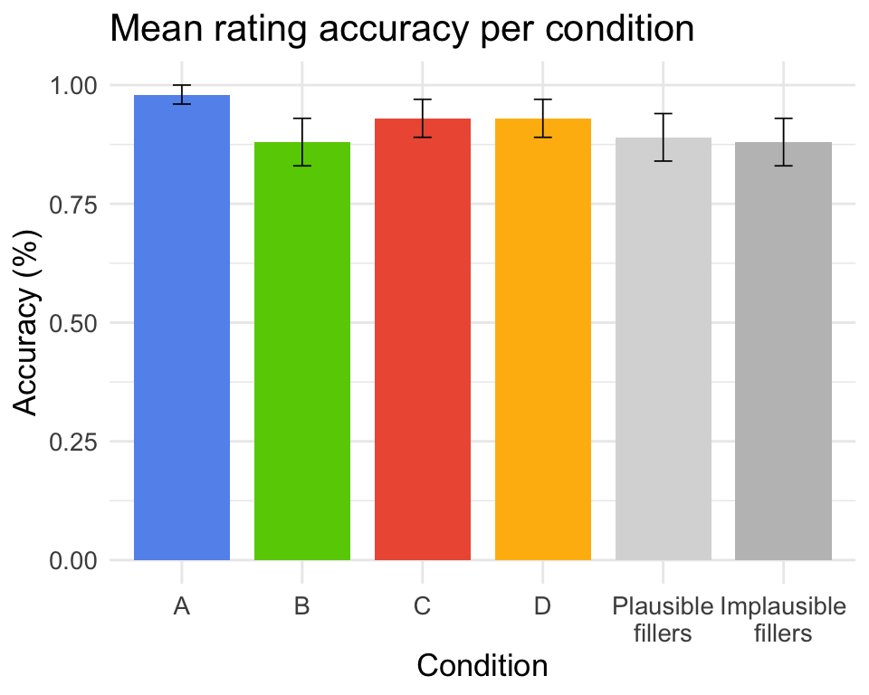

# 4 Rating reaction times

## 4.1 Mean and SD before outlier removal

```r
# Decision Reaction Times
round(mean(ratings$DecisionRT))
```

```
## [1] 1145
```

```r
round(sd(ratings$DecisionRT))
```

```
## [1] 966
```

```r
range(ratings$DecisionRT)
```

```
## [1]   182 16814
```

## 4.2 Remove outliers

First, inspect the histograms and QQ plots of the reaction times to visually check for outliers:

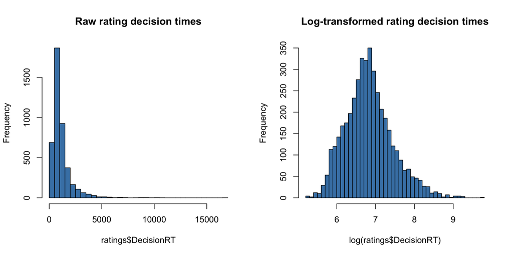

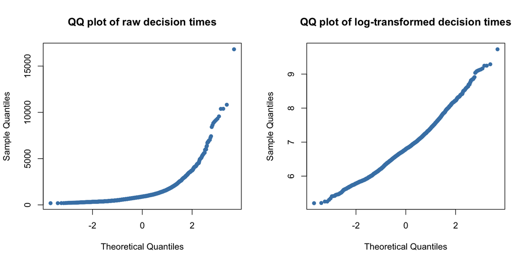

```r
ratings <- removeOutliersRatings(ratings,
                                 method="sd",
                                 sd=2.5)
## Removing outliers values affected 3.43% of the data.
## Data points lost: 148
```

Check the plots again after removing outliers:

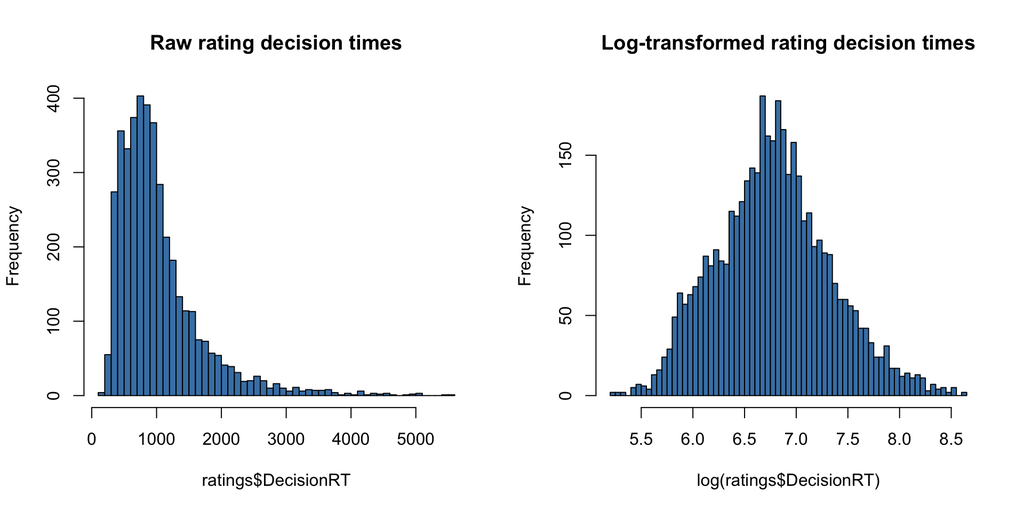

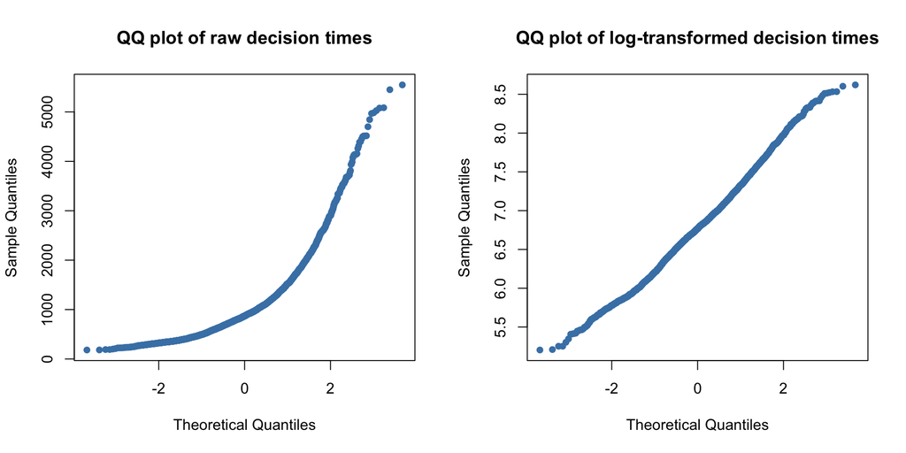

## 4.3 Mean and SD after outlier removal

```r
# Decision Reaction Times
round(mean(ratings$DecisionRT))
```

```
## [1] 1033
```

```r
round(sd(ratings$DecisionRT))
```

```
## [1] 656
```

```r
range(ratings$DecisionRT)
```

```
## [1]  182 5547
```

## 4.4 Reaction time by condition

```r
# Mean and SE of ratings, outliers removed
rating.cond.means <- aggregMeans(ratings,
                                 as.formula(DecisionRT ~ Cond)) %>%
  mutate_if(is.numeric, round)
rating.cond.means
```

```
##                Cond Mean  SD  SE
## 1                 A  983 578  91
## 2                 B 1095 704 111
## 3                 C  902 560  88
## 4                 D  964 583  92
## 5   filler_coherent 1078 667 105
## 6 filler_incoherent 1055 700 111
```

## 4.5 Plot: Reaction times by condition

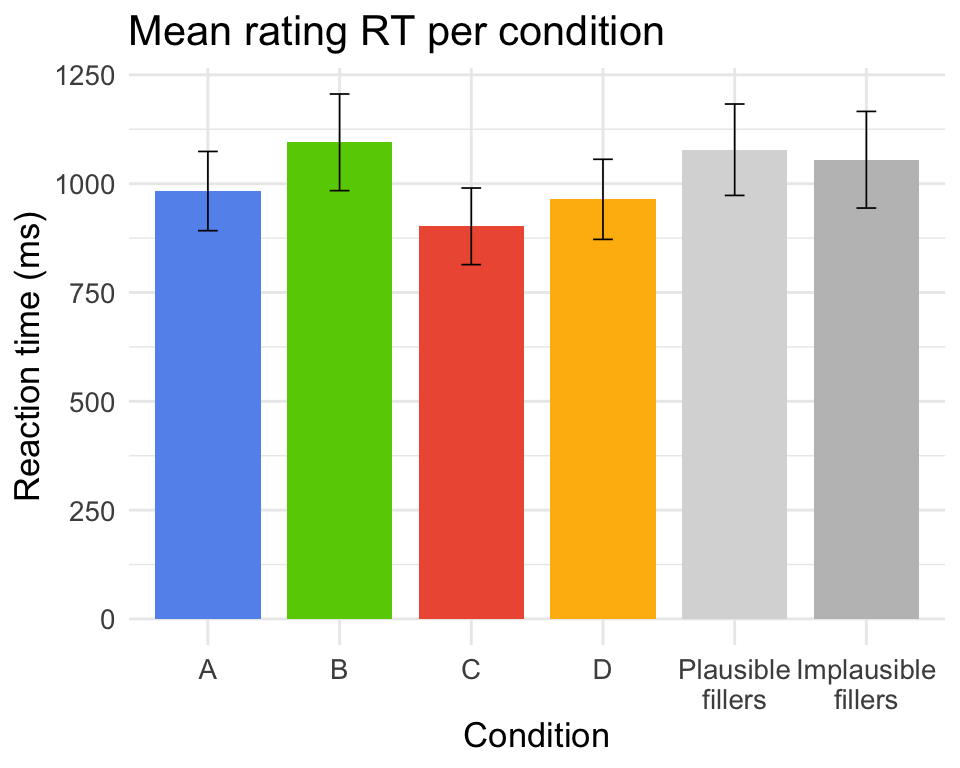